# Project title

by Team-Name: Hannah, Hannah, Rianna

2026-11-27

## Research Question

Research Question Does neighbourhood drive up sale prices in the central area of Ames, Iowa or are other factors more influential at determining sale price?

Sub questions: 1) Is the relationship between quality / condition and price negligible or significant?

2. Does the period of remodelling and original construction heave great significance on sale price?
3. To what extent do structural characteristics play a prominent role in determining sale price in Iowa (e.g. house style and area)?

Research Focus Our focus for researching this particular dataset is to determine the strength of a correlation between the response variable of house sale price, and various explanatory variables including but not limited to house style, area and period of remodelling.

## Data

Data description Our analysis explores the House prices data (collected between 2006 and 2010) which is a dataset, accessed on 30/10/26, consisting of 82 variables and 2930 observations. These variables include the prices of houses sold in Iowa along with their various features, such as basement quality, in addition to structural characteristics stories and overall quality, across different residential areas. The vast spread of data is highly beneficial for providing us with insight into both qualitative and quantitative factors in influencing house prices in Iowa during this period. Thus, enabling us to scale down the data into fewer of both qualitative and quantitative variables (with respect to our question).

Methodology Initially, it was determined most vital to clean the dataset. Our first step for this was to narrow down the location into just the central area using the filter function. We took effort to avoid removing columns unnecessarily as to avoid a bias in our results which would present if other variables i.e. basement quality were deceivingly insignificant. Thereby, as we had not fully confirmed out question, and subsequently concluded our reading on the area of focus, we chose to keep the columns as originally presented. Though, as recommended by the data publishers we did remove a row including an outlier to minimise the possibility of inaccurate interpretations during our initial exploration. The data, in regards to our specific area of focus, did not require extensive cleaning, rather our tidying involved mutating the overwhelmingly large data into smaller specific columns which would allow us to easily interpret the information and allow for efficient comparisons. For example, we transformed the “year built” into general periods i.e. Interwar. As a result, this enabled us to form our research question of: “Does neighbourhood drive up sale prices in the central area of Ames, Iowa or are other factors more influential in dtermining sale price?”, our chosen approach was to divide this broad question into three sub questions: 1) Is the relationship between quality / condition and price negligible or significant? 2) Does the period of remodelling and orginal construction heave great significance on sale price? 3) What is the role of structural characteristics in determining sale price in Iowa (ie house style - stories, area etc.)? Creating relevant visualisations for these sub questions was crucial in our analysis as it not only strengthened our initial understanding of these variables, but reinforced the dominant ideas displayed across these visualisations. For example, we were able to hypothesise from our these visualisations that size is not necessarily the most influential factor in influencing prices of houses sold in Iowa during this time.

## Findings

Initial Exploration & Findings

We stared with visual analyses of how the Prices of Houses in Amez are affected by different factors:

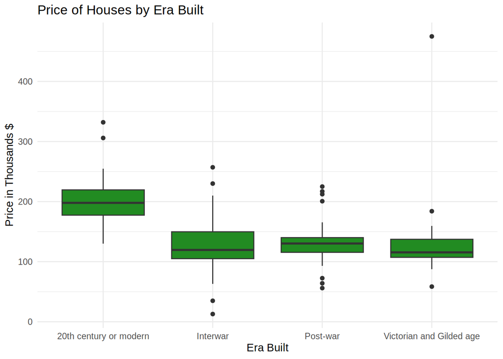

Graph 2) Prices of houses by Era Remodelled: We can see an increasing relationship as median price increases as move closer to recent remodelling. The 1980s&1990s and 2000s have no lower extremes, but high ones (1980s and 1990s has highest extreme).

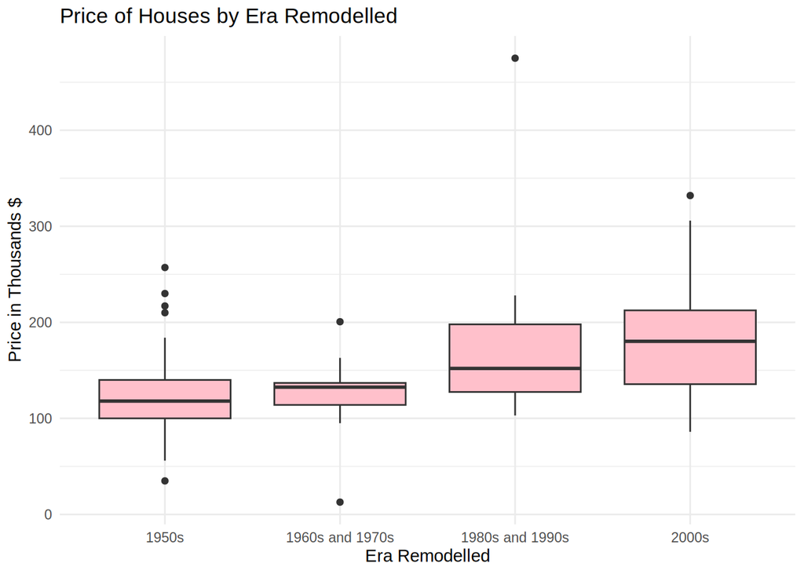

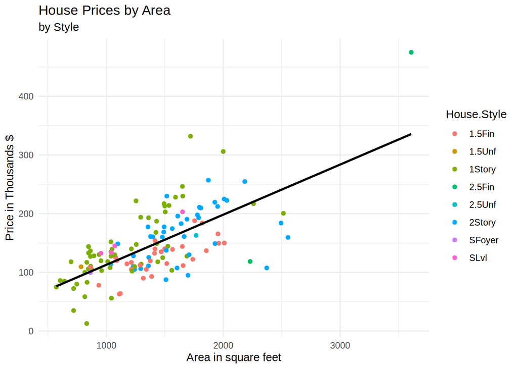

5. Prices of houses by neighbourhood : From thew graph we can see Crawford has the highest average house price, whereas Old Town has the lowest. Edwards, IDOTRR, SWISU and Brookside have relatively similar average prices, clustering within the $100,000–$150,000 range. Interestingly, Old Town also displays the widest range of prices, containing both the highest and lowest extreme values, suggesting considerable variation in house prices within the neighbourhood.